# Clasificación Imágenes

crsd

25 de febrero de 2019

```r
suppressMessages(library(EBImage))
suppressMessages(library(readbitmap))
suppressMessages(library(fftwtools))
suppressMessages(library(rgl))
suppressMessages(library(ggplot2))
suppressMessages(library(caret))
suppressMessages(library(MASS))
suppressMessages(library(dplyr))

source("fftshift.R") # centra el espectro de frecuencias
source("PCE.R") # Calcula PCE
source("PSR.R") # Calcula PSR
source("DC.R") # Calcula DC
source("ExtCaract.R") # Hace pruebas y extrae caracteristicas PCE, PSR y DC para graficos
source("ExtCaract2.R") # Hace pruebas y extrae caracteristicas PCE, PSR y DC para modelado
source("reg_face.R") # Genera modelos de regresion y clasificacion
source("UnitTest.R") # Clasifica una imagen
source("F_random.R") # Crea un filtro POF aleatorio (filtros, imagen en frecuencia y autocorrelaciones)
```

# Resumen

Continuando con el trabajo de [Reconocimiento de Imagenes por Correlacion](https://rpubs.com/desareca/Reconocimiento-Imagenes-Correlacion), desarrollaremos un clasificador para los 13 sujetos.

EL objetivo es construir un clasificador a partir de sólo una imagen de cada sujeto y para esto seguiremos la siguiente estrategia:

- Extraeremos las carácterísticas de PCE, PSR y DC de 13 filtros (uno por sujeto) aplicados a una imagen de prueba aleatoria.
- Con estas pruebas construiremos 13 modelos de regresión para estimar si la imagen de prueba pertenece a una clase.
- Estas regresiones se utilizarán para desarrallar un clasificador final.
- Para finalizar se aplicará ruido a algunas imágenes para evaluar el desempeño del clasificador.

# Extraccion de cararterísticas

Para extraer características se considera el filtro POF (ver [Reconocimiento de Imagenes por Correlacion](https://rpubs.com/desareca/Reconocimiento-Imagenes-Correlacion)), ya que se observa una clara posibilidad de separar en regiones distintas (sujeto de impostor) de acuerdo a las variables PCE, PSR y DC.

Con este fin, se considera realizar 1000 observaciones, donde cada observacion considera extraer el PSR, PCE y DC de una imagen con 13 filtros POF (uno por sujeto). Para el caso de la DC se considera como auto correlación a la imagen con que se diseñó cada filtro.

Una vez obtenidas las observaciones, vamos a separar los datos en conjunto de entrenamiento, pruebas y validación, con 50%, 30% y 20% respectivamente.

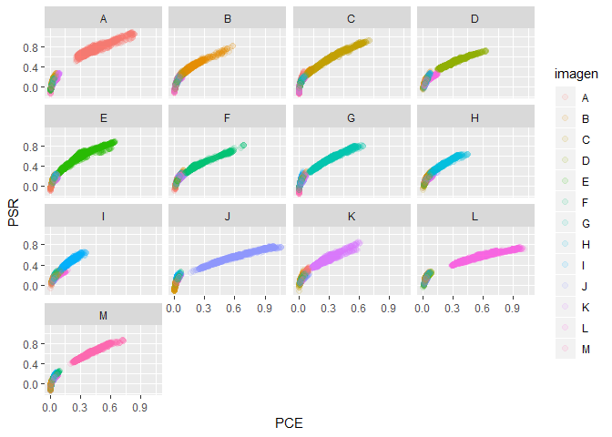

```r
dir1="./faceExpressionDatabase/"
Subject = LETTERS[1:13]
Number = c("00", "01", "02", "03", "04", "05", "06", "07", "08", "09",
           "10", "11", "12", "13", "14", "15", "16", "17", "18", "19",
           "20", "21", "22", "23", "24", "25", "26", "27", "28", "29",
           "30", "31", "32", "33", "34", "35", "36", "37", "38", "39",
           "40", "41", "42", "43", "44", "45", "46", "47", "48", "49",
           "50", "51", "52", "53", "54", "55", "56", "57", "58", "59",
           "60", "61", "62", "63", "64", "65", "66", "67", "68", "69",
           "70", "71", "72", "73", "74")
n=1000 # numero de pruebas (el numero de observaciones es 13*n) (100 muestras son 2 minutos)

PLOT <- ExtCaract(n=n, seed = 50, dir1 = dir1, Subject = Subject, Number = Number)
DATA <- ExtCaract2(n=n, seed = 50, dir1 = dir1, Subject = Subject, Number = Number)

set.seed(28916022)
Index1 <- createDataPartition(y = DATA$imagen, p = 0.5, list = FALSE)
TEST <- DATA[-Index1,]
TRAIN <- DATA[Index1,]
Index2 <- createDataPartition(y = TEST$imagen, p = 0.6, list = FALSE)
VAL <- TEST[-Index2,]
TEST <- TEST[Index2,]

saveRDS(TRAIN, "train_set_pof.rds")
saveRDS(TEST, "test_set_pof.rds")
saveRDS(VAL, "Valid_set_pof.rds")

remove(DC, fftshift, PCE, PSR, Index1, DATA, dir1, Index2, Number, Subject,n)

ggplot(PLOT, aes(PCE, PSR, color = imagen)) +
      geom_point(size = 2, alpha = 0.1) + facet_wrap(~filtro)
```

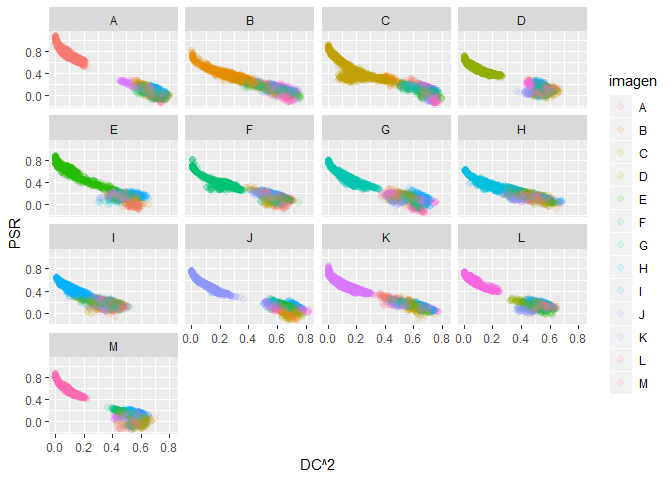

```r
ggplot(PLOT, aes(DC^2, PSR, color = imagen)) +
      geom_point(size = 2, alpha = 0.1) + facet_wrap(~filtro)
```

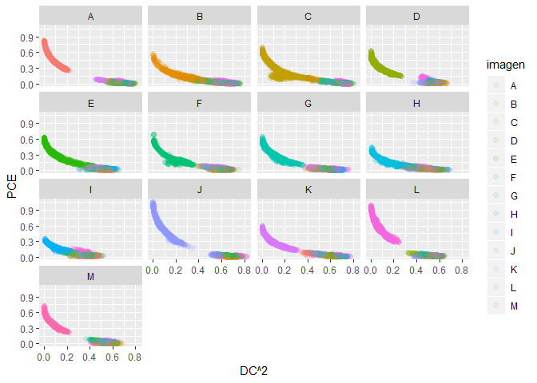

```r
ggplot(PLOT, aes(DC^2, PCE, color = imagen)) +
      geom_point(size = 2, alpha = 0.1) + facet_wrap(~filtro)
```

Observando los gráficos podemos ver que para cada filtro hay una región que se puede asociar al sujeto con que se diseñó el filtro y los impostores. Esto es en algunos casos más evidente como es el caso del sujeto **“A”** y en otros no tanto como en el sujeto **“B”**. En cualquier caso podemos aplicar algún modelo que prediga esto.

Si observamos el gráfico de PCE VS PSR, tenemos que para cada filtro la imagen asociada a su clase tiene valores altos de PCE y PSR y los impostores al filtro tienen valores bajos, esto se debe a que valores altos en PSR y PCE indican una mayor relación entre la información del filtro y la imagen aplicada.

En el caso de la DC, tenemos que las imagenes asociadas a la clase del filtro tienen valores pequeños y los impostores altos, esto es debido a que al filtrotiene menor capacidad para discrimanar enrte la imagen con que se diseñó el filtro y una imagen de la misma clase (reconoce a ambas como válidas).

# Modelos de regresión

Para los modelos de regresión utilizaremos el método **Bayesglm**, este es una simple alteración a un algoritmo de un modelos lineal generalizado (**glm**). Para mayor información revisar:

https://www.rdocumentation.org/packages/arm/versions/1.10-1/topics/bayesglm

En este caso se toman las variables extraidas anteriormente asociadas a la clase de un filtro en particular con la clase de imagen de prueba. Si la imagen de prueba pertenece a la clase del filtro se asigna un **1**, en caso contrario se asigna un **0**, esto se repite para cada filtro.

Para desarrollar los modelos de regresión consideraremos para entrenamiento al conjunto de pruebas utilizando validación cruzada con 5 folds y para las pruebas el conjunto de pruebas determinados anteriormente.

A continuación se muestran los resultados aplicando el conjunto de prueba a cada modelos de regresión. Se aprecia una clara tendencia a filtrar el rostro asociado a la clase para la que fue diseñado y a rechazar el resto.

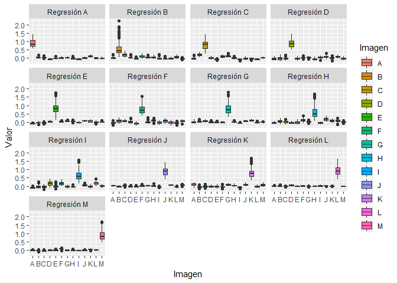

```r
Resultado <- reg_face(TRAIN, TEST, VAL, method1 = "bayesglm", method2="LogitBoost",
                    trC=trainControl(method="cv", number=5))

test <- readRDS("TestReg_bayesglm_LogitBoost.rds")
colnames(test) <- c("Regresión A", "Regresión B", "Regresión C", "Regresión D",
                    "Regresión E", "Regresión F", "Regresión G", "Regresión H",
                    "Regresión I", "Regresión J", "Regresión K", "Regresión L",
                    "Regresión M", "Imagen")
tt <- test[, c(1,14)]
tt <- cbind(tt, colnames(test)[1])
colnames(tt) <- c("Valor", "Imagen", "Regresion")
for (i in 2:13) {
      a <- test[, c(i,14)]
      a <- cbind(a, colnames(test)[i])
      colnames(a) <- c("Valor", "Imagen", "Regresion")
      tt <- rbind(tt, a)
}

ggplot(data=tt, aes(Imagen, Valor,fill=Imagen)) +  geom_boxplot() + facet_wrap(~Regresion)
```

# Clasificador

Para el calasificador utilizaremos el método **LogitBoost**, este es un algoritmo basado en arboldes de decisión. Para mayor información revisar:

https://www.rdocumentation.org/packages/caTools/versions/1.17.1/topics/LogitBoost

Para diseñar el clasificador, consideraremos para entrenamiento al conjunto de pruebas utilizando validación cruzada con 5 folds.

```r
readRDS("FitClass_bayesglm_LogitBoost.rds")
```

```
Boosted Logistic Regression

3900 samples
  13 predictor
  13 classes: 'A', 'B', 'C', 'D', 'E', 'F', 'G', 'H', 'I', 'J', 'K', 'L', 'M'

No pre-processing
Resampling: Cross-Validated (5 fold)
Summary of sample sizes: 3120, 3120, 3120, 3120, 3120
Resampling results across tuning parameters:

  nIter  Accuracy   Kappa
  11     0.9984553  0.9983265
  21     0.9984606  0.9983323
  31     0.9982051  0.9980556

Accuracy was used to select the optimal model using the largest value.
The final value used for the model was nIter = 21.
```

Las pruebas de desempeño se realizarán con el conjunto de validación, tal como se muestra acontinuación:

```r
Resultado
```

```
Confusion Matrix and Statistics

          Reference
Prediction   A   B   C   D   E   F   G   H   I   J   K   L   M
         A 200   0   0   0   0   0   0   0   0   0   0   0   0
         B   0 199   0   0   0   0   0   0   0   0   0   0   0
         C   0   0 198   0   0   0   0   0   0   0   0   0   0
         D   0   0   0 200   0   0   0   0   0   0   0   0   0
         E   0   0   0   0 200   0   0   0   0   0   0   0   0
         F   0   0   0   0   0 200   0   0   0   0   0   0   0
         G   0   0   0   0   0   0 200   0   0   0   0   0   0
         H   0   0   0   0   0   0   0 200   0   0   0   0   0
         I   0   0   0   0   0   0   0   0 198   0   0   0   0
         J   0   0   0   0   0   0   0   0   0 200   0   0   0
         K   0   0   0   0   0   0   0   0   0   0 200   0   0
         L   0   0   0   0   0   0   0   0   0   0   0 200   0
         M   0   0   0   0   0   0   0   0   0   0   0   0 200

Overall Statistics

               Accuracy : 1
                 95% CI : (0.9986, 1)
    No Information Rate : 0.0771
    P-Value [Acc > NIR] : < 2.2e-16

                  Kappa : 1
 Mcnemar's Test P-Value : NA

Statistics by Class:

                     Class: A Class: B Class: C Class: D Class: E Class: F
Sensitivity           1.00000  1.00000   1.0000  1.00000  1.00000  1.00000
Specificity           1.00000  1.00000   1.0000  1.00000  1.00000  1.00000
Pos Pred Value        1.00000  1.00000   1.0000  1.00000  1.00000  1.00000
Neg Pred Value        1.00000  1.00000   1.0000  1.00000  1.00000  1.00000
Prevalence            0.07707  0.07669   0.0763  0.07707  0.07707  0.07707
Detection Rate        0.07707  0.07669   0.0763  0.07707  0.07707  0.07707
Detection Prevalence  0.07707  0.07669   0.0763  0.07707  0.07707  0.07707
Balanced Accuracy     1.00000  1.00000   1.0000  1.00000  1.00000  1.00000
                     Class: G Class: H Class: I Class: J Class: K Class: L
Sensitivity           1.00000  1.00000   1.0000  1.00000  1.00000  1.00000
Specificity           1.00000  1.00000   1.0000  1.00000  1.00000  1.00000
Pos Pred Value        1.00000  1.00000   1.0000  1.00000  1.00000  1.00000
Neg Pred Value        1.00000  1.00000   1.0000  1.00000  1.00000  1.00000
Prevalence            0.07707  0.07707   0.0763  0.07707  0.07707  0.07707
Detection Rate        0.07707  0.07707   0.0763  0.07707  0.07707  0.07707
Detection Prevalence  0.07707  0.07707   0.0763  0.07707  0.07707  0.07707
Balanced Accuracy     1.00000  1.00000   1.0000  1.00000  1.00000  1.00000
                     Class: M
Sensitivity           1.00000
Specificity           1.00000
Pos Pred Value        1.00000
Neg Pred Value        1.00000
Prevalence            0.07707
Detection Rate        0.07707
Detection Prevalence  0.07707
Balanced Accuracy     1.00000
```

# Pruebas con ruido

El clasificador muestra un muy buen desempeño, para probarlo aún más utilizaremos otro conjunto de pruebas adicional y le agregaremos ruido tal como se muestra en el siguiente ejemplo:

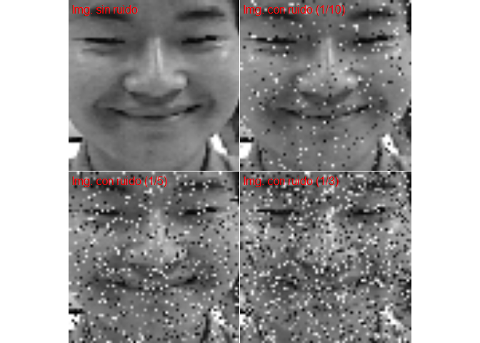

```r
# carga imagen de prueba
dir1="./faceExpressionDatabase/"
img = Image(rotate(read.bitmap(paste0(dir1,"A","22",".bmp"))/255,
                   angle = 90))
# genera ruido uniforme
img_noisy1 = img
img_noisy2 = img
img_noisy3 = img
set.seed(900)
img_noisy1[sample(length(img), length(img)/10)] = runif(length(img)/10, min=0, max=1)
img_noisy2[sample(length(img), length(img)/5)] = runif(length(img)/5, min=0, max=1)
img_noisy3[sample(length(img), length(img)/3)] = runif(length(img)/3, min=0, max=1)

# muestra imagenes
display(EBImage::combine(img, img_noisy1, img_noisy2, img_noisy3),
        all=TRUE, method = "raster")
text(x = 2, y = 2, label = "Img. sin ruido", adj = c(0,1),
     col = "red", cex = 1)
text(x = 64 + 2, y = 2, label = "Img. con ruido (1/10)", adj = c(0,1),
     col = "red", cex = 1)
text(x = 2, y = 64 + 2, label = "Img. con ruido (1/5)", adj = c(0,1),
     col = "red", cex = 1)
text(x = 64 + 2, y = 64 + 2, label = "Img. con ruido (1/3)", adj = c(0,1),
                               col = "red", cex = 1)
```

El ruido considera aplicar a una proporción de la imagen ruido uniforme, por ejemplo ruido (1/10) quiere decir que se aplicará ruido uniforme al 1/10 de pixeles de la imagen.

Para el conjunto de pruebas con ruido consideraremos tomar 50 muestras aleatorias por cada clase y asignarle ruido en proporcion 1/10, 1/5 y 1/3.

Acontinuación se muestra la matriz de confusión de las imagenes sin ruido, con una precisión de 100%.

```r
# Genera filtros aleatoriamente
Filtros <- F_random(seed = 750)
# Carga modelos de regresion
fitLOG_A <- readRDS("fitReg_bayesglm_LogitBoost_A.rds")
fitLOG_B <- readRDS("fitReg_bayesglm_LogitBoost_B.rds")
fitLOG_C <- readRDS("fitReg_bayesglm_LogitBoost_C.rds")
fitLOG_D <- readRDS("fitReg_bayesglm_LogitBoost_D.rds")
fitLOG_E <- readRDS("fitReg_bayesglm_LogitBoost_E.rds")
fitLOG_F <- readRDS("fitReg_bayesglm_LogitBoost_F.rds")
fitLOG_G <- readRDS("fitReg_bayesglm_LogitBoost_G.rds")
fitLOG_H <- readRDS("fitReg_bayesglm_LogitBoost_H.rds")
fitLOG_I <- readRDS("fitReg_bayesglm_LogitBoost_I.rds")
fitLOG_J <- readRDS("fitReg_bayesglm_LogitBoost_J.rds")
fitLOG_K <- readRDS("fitReg_bayesglm_LogitBoost_K.rds")
fitLOG_L <- readRDS("fitReg_bayesglm_LogitBoost_L.rds")
fitLOG_M <- readRDS("fitReg_bayesglm_LogitBoost_M.rds")
# Carga modelo de clasificacion
fitclass <- readRDS("FitClass_bayesglm_LogitBoost.rds")
# Genera pruebas para 50 rostros con cada tipo con ruido
n=50
Number = c("00", "01", "02", "03", "04", "05", "06", "07", "08", "09",
           "10", "11", "12", "13", "14", "15", "16", "17", "18", "19",
           "20", "21", "22", "23", "24", "25", "26", "27", "28", "29",
           "30", "31", "32", "33", "34", "35", "36", "37", "38", "39",
           "40", "41", "42", "43", "44", "45", "46", "47", "48", "49",
           "50", "51", "52", "53", "54", "55", "56", "57", "58", "59",
           "60", "61", "62", "63", "64", "65", "66", "67", "68", "69",
           "70", "71", "72", "73", "74")
set.seed(200)
Class_IMG <- data.frame()
Class_IMG1 <- data.frame()
Class_IMG2 <- data.frame()
Class_IMG3 <- data.frame()
l<-1
for (i in 1:13) {
      for (k in 1:n) {
            # carga indices aleatorios
            SubjectP <- LETTERS[i]
            NP <- sample(Number, 1, replace = TRUE)
            # lee imagen y agrega ruido
            img = Image(rotate(read.bitmap(paste0(dir1,SubjectP,NP,".bmp"))/255,angle = 90))
            img_noisy1 = img
            img_noisy2 = img
            img_noisy3 = img
            img_noisy1[sample(length(img), length(img)/10)] = runif(length(img)/10, min=0, max=1)
            img_noisy2[sample(length(img), length(img)/5)] = runif(length(img)/5, min=0, max=1)
            img_noisy3[sample(length(img), length(img)/3)] = runif(length(img)/3, min=0, max=1)
            # Clasifica las imagenes
            IMG <- UnitTest(img/64/64, fitLOG_A, fitLOG_B, fitLOG_C, fitLOG_D, fitLOG_E, fitLOG_F,
                            fitLOG_G, fitLOG_H, fitLOG_I, fitLOG_K, fitLOG_L, fitLOG_M,
                            fitclass, seed = 20)
            IMG1 <- UnitTest(img_noisy1/64/64, fitLOG_A, fitLOG_B, fitLOG_C, fitLOG_D, fitLOG_E, fitLOG_F,
                             fitLOG_G, fitLOG_H, fitLOG_I, fitLOG_K, fitLOG_L, fitLOG_M,
                             fitclass, seed = 20)
            IMG2 <- UnitTest(img_noisy2/64/64, fitLOG_A, fitLOG_B, fitLOG_C, fitLOG_D, fitLOG_E, fitLOG_F,
                             fitLOG_G, fitLOG_H, fitLOG_I, fitLOG_K, fitLOG_L, fitLOG_M,
                             fitclass, seed = 20)
            IMG3 <- UnitTest(img_noisy3/64/64, fitLOG_A, fitLOG_B, fitLOG_C, fitLOG_D, fitLOG_E, fitLOG_F,
                             fitLOG_G, fitLOG_H, fitLOG_I, fitLOG_K, fitLOG_L, fitLOG_M,
                             fitclass, seed = 20)
            # guarda la clasificacion
            Class_IMG[l,1] <- IMG
            Class_IMG[l,2] <- SubjectP
            Class_IMG1[l,1] <- IMG1
            Class_IMG1[l,2] <- SubjectP
            Class_IMG2[l,1] <- IMG2
            Class_IMG2[l,2] <- SubjectP
            Class_IMG3[l,1] <- IMG3
            Class_IMG3[l,2] <- SubjectP
            l<-l+1
      }
}
colnames(Class_IMG) <- c("Clasificacion", "Referencia")
colnames(Class_IMG1) <- c("Clasificacion", "Referencia")
colnames(Class_IMG2) <- c("Clasificacion", "Referencia")
colnames(Class_IMG3) <- c("Clasificacion", "Referencia")
Class_IMG$Clasificacion <- factor(Class_IMG$Clasificacion)
Class_IMG$Referencia <- factor(Class_IMG$Referencia)
Class_IMG1$Clasificacion <- factor(Class_IMG1$Clasificacion)
Class_IMG1$Referencia <- factor(Class_IMG1$Referencia)
Class_IMG2$Clasificacion <- factor(Class_IMG2$Clasificacion)
Class_IMG2$Referencia <- factor(Class_IMG2$Referencia)
Class_IMG3$Clasificacion <- factor(Class_IMG3$Clasificacion)
Class_IMG3$Referencia <- factor(Class_IMG3$Referencia)
# Genera matriz de confusion
CM0 <- confusionMatrix(Class_IMG$Clasificacion, Class_IMG$Referencia)
CM1 <- confusionMatrix(Class_IMG1$Clasificacion, Class_IMG1$Referencia)
CM2 <- confusionMatrix(Class_IMG2$Clasificacion, Class_IMG2$Referencia)
CM3 <- confusionMatrix(Class_IMG3$Clasificacion, Class_IMG3$Referencia)
CM0
```

```
Confusion Matrix and Statistics

          Reference
Prediction  A  B  C  D  E  F  G  H  I  J  K  L  M
         A 50  0  0  0  0  0  0  0  0  0  0  0  0
         B  0 50  0  0  0  0  0  0  0  0  0  0  0
         C  0  0 50  0  0  0  0  0  0  0  0  0  0
         D  0  0  0 50  0  0  0  0  0  0  0  0  0
         E  0  0  0  0 50  0  0  0  0  0  0  0  0
         F  0  0  0  0  0 50  0  0  0  0  0  0  0
         G  0  0  0  0  0  0 50  0  0  0  0  0  0
         H  0  0  0  0  0  0  0 50  0  0  0  0  0
         I  0  0  0  0  0  0  0  0 50  0  0  0  0
         J  0  0  0  0  0  0  0  0  0 50  0  0  0
         K  0  0  0  0  0  0  0  0  0  0 50  0  0
         L  0  0  0  0  0  0  0  0  0  0  0 50  0
         M  0  0  0  0  0  0  0  0  0  0  0  0 50

Overall Statistics

               Accuracy : 1
                 95% CI : (0.9943, 1)
    No Information Rate : 0.0769
    P-Value [Acc > NIR] : < 2.2e-16

                  Kappa : 1
 Mcnemar's Test P-Value : NA

Statistics by Class:

                     Class: A Class: B Class: C Class: D Class: E Class: F
Sensitivity           1.00000  1.00000  1.00000  1.00000  1.00000  1.00000
Specificity           1.00000  1.00000  1.00000  1.00000  1.00000  1.00000
Pos Pred Value        1.00000  1.00000  1.00000  1.00000  1.00000  1.00000
Neg Pred Value        1.00000  1.00000  1.00000  1.00000  1.00000  1.00000
Prevalence            0.07692  0.07692  0.07692  0.07692  0.07692  0.07692
Detection Rate        0.07692  0.07692  0.07692  0.07692  0.07692  0.07692
Detection Prevalence  0.07692  0.07692  0.07692  0.07692  0.07692  0.07692
Balanced Accuracy     1.00000  1.00000  1.00000  1.00000  1.00000  1.00000
                     Class: G Class: H Class: I Class: J Class: K Class: L
Sensitivity           1.00000  1.00000  1.00000  1.00000  1.00000  1.00000
Specificity           1.00000  1.00000  1.00000  1.00000  1.00000  1.00000
Pos Pred Value        1.00000  1.00000  1.00000  1.00000  1.00000  1.00000
Neg Pred Value        1.00000  1.00000  1.00000  1.00000  1.00000  1.00000
Prevalence            0.07692  0.07692  0.07692  0.07692  0.07692  0.07692
Detection Rate        0.07692  0.07692  0.07692  0.07692  0.07692  0.07692
Detection Prevalence  0.07692  0.07692  0.07692  0.07692  0.07692  0.07692
Balanced Accuracy     1.00000  1.00000  1.00000  1.00000  1.00000  1.00000
                     Class: M
Sensitivity           1.00000
Specificity           1.00000
Pos Pred Value        1.00000
Neg Pred Value        1.00000
Prevalence            0.07692
Detection Rate        0.07692
Detection Prevalence  0.07692
Balanced Accuracy     1.00000
```

```r
CM1
```

```
Confusion Matrix and Statistics

          Reference
Prediction  A  B  C  D  E  F  G  H  I  J  K  L  M
         A 50  0  0  0  0  0  0  0  0  0  0  0  0
         B  0 50  0  0  0  0  0  0 50  0  0  0  0
         C  0  0 50  0  0  0  0  0  0  0  0  0  0
         D  0  0  0 50  0  0  0  0  0  0  0  0  0
         E  0  0  0  0 50  0  0  0  0  0  0  0  0
         F  0  0  0  0  0 50  0  0  0  0  0  0  0
         G  0  0  0  0  0  0 50  0  0  0  0  0  0
         H  0  0  0  0  0  0  0 50  0  0  0  0  0
         I  0  0  0  0  0  0  0  0  0  0  0  0  0
         J  0  0  0  0  0  0  0  0  0 50  0  0  0
         K  0  0  0  0  0  0  0  0  0  0 50  0  0
         L  0  0  0  0  0  0  0  0  0  0  0 50  0
         M  0  0  0  0  0  0  0  0  0  0  0  0 50

Overall Statistics

               Accuracy : 0.9231
                 95% CI : (0.8998, 0.9424)
    No Information Rate : 0.0769
    P-Value [Acc > NIR] : < 2.2e-16

                  Kappa : 0.9167
 Mcnemar's Test P-Value : NA

Statistics by Class:

                     Class: A Class: B Class: C Class: D Class: E Class: F
Sensitivity           1.00000  1.00000  1.00000  1.00000  1.00000  1.00000
Specificity           1.00000  0.91667  1.00000  1.00000  1.00000  1.00000
Pos Pred Value        1.00000  0.50000  1.00000  1.00000  1.00000  1.00000
Neg Pred Value        1.00000  1.00000  1.00000  1.00000  1.00000  1.00000
Prevalence            0.07692  0.07692  0.07692  0.07692  0.07692  0.07692
Detection Rate        0.07692  0.07692  0.07692  0.07692  0.07692  0.07692
Detection Prevalence  0.07692  0.15385  0.07692  0.07692  0.07692  0.07692
Balanced Accuracy     1.00000  0.95833  1.00000  1.00000  1.00000  1.00000
                     Class: G Class: H Class: I Class: J Class: K Class: L
Sensitivity           1.00000  1.00000  0.00000  1.00000  1.00000  1.00000
Specificity           1.00000  1.00000  1.00000  1.00000  1.00000  1.00000
Pos Pred Value        1.00000  1.00000      NaN  1.00000  1.00000  1.00000
Neg Pred Value        1.00000  1.00000  0.92308  1.00000  1.00000  1.00000
Prevalence            0.07692  0.07692  0.07692  0.07692  0.07692  0.07692
Detection Rate        0.07692  0.07692  0.00000  0.07692  0.07692  0.07692
Detection Prevalence  0.07692  0.07692  0.00000  0.07692  0.07692  0.07692
Balanced Accuracy     1.00000  1.00000  0.50000  1.00000  1.00000  1.00000
                     Class: M
Sensitivity           1.00000
Specificity           1.00000
Pos Pred Value        1.00000
Neg Pred Value        1.00000
Prevalence            0.07692
Detection Rate        0.07692
Detection Prevalence  0.07692
Balanced Accuracy     1.00000
```

```r
CM2
```

[output not shown]

```r
CM3
```

```
Confusion Matrix and Statistics

          Reference
Prediction  A  B  C  D  E  F  G  H  I  J  K  L  M
         A 50  0  0  0  0  0  0  0  0  0  0  0  0
         B  0 50  0  0  0  0  0  0 50  0  0  0  0
         C  0  0 50  0  0  0  0  0  0  0  0  0  0
         D  0  0  0 50  0  0  0  0  0  0  0  0  0
         E  0  0  0  0 50  0  0  0  0  0  0  0  0
         F  0  0  0  0  0 50  0  0  0  0  0  0  0
         G  0  0  0  0  0  0 50  0  0  0  0  0  0
         H  0  0  0  0  0  0  0 50  0  0  0  0  0
         I  0  0  0  0  0  0  0  0  0  0  0  0  0
         J  0  0  0  0  0  0  0  0  0 50  0  0  0
         K  0  0  0  0  0  0  0  0  0  0 50  0  0
         L  0  0  0  0  0  0  0  0  0  0  0 50  0
         M  0  0  0  0  0  0  0  0  0  0  0  0 50

Overall Statistics

               Accuracy : 0.9231
                 95% CI : (0.8998, 0.9424)
    No Information Rate : 0.0769
    P-Value [Acc > NIR] : < 2.2e-16

                  Kappa : 0.9167
 Mcnemar's Test P-Value : NA

Statistics by Class:

                     Class: A Class: B Class: C Class: D Class: E Class: F
Sensitivity           1.00000  1.00000  1.00000  1.00000  1.00000  1.00000
Specificity           1.00000  0.91667  1.00000  1.00000  1.00000  1.00000
Pos Pred Value        1.00000  0.50000  1.00000  1.00000  1.00000  1.00000
Neg Pred Value        1.00000  1.00000  1.00000  1.00000  1.00000  1.00000
Prevalence            0.07692  0.07692  0.07692  0.07692  0.07692  0.07692
Detection Rate        0.07692  0.07692  0.07692  0.07692  0.07692  0.07692
Detection Prevalence  0.07692  0.15385  0.07692  0.07692  0.07692  0.07692
Balanced Accuracy     1.00000  0.95833  1.00000  1.00000  1.00000  1.00000
                     Class: G Class: H Class: I Class: J Class: K Class: L
Sensitivity           1.00000  1.00000  0.00000  1.00000  1.00000  1.00000
Specificity           1.00000  1.00000  1.00000  1.00000  1.00000  1.00000
Pos Pred Value        1.00000  1.00000      NaN  1.00000  1.00000  1.00000
Neg Pred Value        1.00000  1.00000  0.92308  1.00000  1.00000  1.00000
Prevalence            0.07692  0.07692  0.07692  0.07692  0.07692  0.07692
Detection Rate        0.07692  0.07692  0.00000  0.07692  0.07692  0.07692
Detection Prevalence  0.07692  0.07692  0.00000  0.07692  0.07692  0.07692
Balanced Accuracy     1.00000  1.00000  0.50000  1.00000  1.00000  1.00000
                     Class: M
Sensitivity           1.00000
Specificity           1.00000
Pos Pred Value        1.00000
Neg Pred Value        1.00000
Prevalence            0.07692
Detection Rate        0.07692
Detection Prevalence  0.07692
Balanced Accuracy     1.00000
```

# Conclusiones

El clasificador presenta un buen desempeño (99.846%) para todas las clases. Al aplicar ruido a las imágenes, el desempeño decae a 92.31%, aunque todavía es un buen desempeño.

Para resolver esto, se puede aplicar un filtro para el ruido, en particular el filtro de mediana es una excelente opción para este tipo de ruido.

La ejecución del filtro es bastante rápido, pero requiere tener cargado de antemano los 13 modelos de regresión y el modelo de clasificación. Además de las transformadas de fourier de las imagenes de diseño de los filtros y los filtros de correlación.

Este filtro tiene la ventaja de poder ser diseñado con sólo una imagen para cada filtro. En caso de querer agregar otra clase se debe realizar la regresión para la nueva clase y entrenar nuevamente el clasificador con las clases anteriores y la nueva, por lo que ampliarlo es relativamente sencillo.

Una incertidumbre es el desempeño del filtro para imagenes tomadas en distintas condiciones de luz, foco, contraste, etc. ya que en este caso todas las imagenes están tomadas con las mismas condiciones. Por lo que un paso siguiente sería evaluar el clasificador con imagenes en distintas condiciones.

Otro paso a seguir sería probar el clasificador ante cambios de posición, ya que los valores de los peak de correlación cambian con la posición y es posible que el clasificador (y los modelos de regresión) deba ser reentrenado completamente.

# Referencia

Para revisar el código de este trabajo ir a:

https://github.com/desareca/Procesamiento-Imagenes-R